## Library Imports

```python
# Import Python standard libraries:
import logging
from typing import Union
import json, sys, platform
import joblib
from pathlib import Path
import warnings
warnings.filterwarnings("ignore")

# Import 3rd party libraries:
import pandas as pd
import numpy as np
import matplotlib.pyplot as plt
import seaborn as sns
import lightgbm as lgb
from sklearn.model_selection import train_test_split
from sklearn.model_selection import GridSearchCV
from scipy.stats import ttest_rel
import matplotlib as mpl
import matplotlib.pyplot as plt
from matplotlib.axes import Axes
from matplotlib.figure import Figure
from matplotlib.lines import Line2D
from sklearn.metrics import auc

# Local imports:
import shapfire.utils as utils
from data.utils import import_and_preprocess_data
from data.features import categorical_features, numerical_features, drop_features, feature_name_mapping
from shapfire import ShapFire, RefitHelper, plot_roc_curve, hyperparameter_search_helper, ShapFirePlottingInterface
```

# 0. Data Management & Preprocessing

## 0.1 Import & Preprocess Data (Create Datasets D1/D2)

The following cell relies on function `import_and_preprocess_data` to load and prepare a dataset for modeling. It uses a given CSV file when provided; otherwise falls back to a previously saved, subgroup-annotated CSV file (enabling reproducible reruns that reuse existing dataset splits).

**Behavior:**

- **default mode:** When `dataset_path` is provided and exists, the function
  1. reads the CSV,
  2. cleans/casts columns using imported lists: `numerical_features` and `categorical_features`,
  3. splits into preprocess/final sets with scikit-learn's `train_test_split`, and
  4. saves the organized data with a `subgroup` column (`0` for identifying the preprocessing dataset, `1` for identifying the final evaluation dataset) to directory `organized_subgroups_path`.
- **Fallback mode:** When `dataset_path` is `None`, it loads the file at `organized_subgroups_path` and reconstructs the two splits from the previously-created `subgroup` column.

**Returns:**

- `X_preprocess` (`pd.DataFrame`)
- `X_final` (`pd.DataFrame`)
- `y_preprocess` (`pd.Series`)
- `y_final` (`pd.Series`)

Here `X_preprocess` and `y_preprocess` correspond to the preprocessing dataset (D1, `subgroup = 0`), which is used for feature ranking/selection and machine learning hyperparameter tuning (via cross-validation). On the other hand, `X_final` and `y_final` correspond to the held-out dataset (D2, `subgroup = 1`), which is used exclusively to obtain unbiased ROC AUC performance estimates after features and hyperparameters have been selected/tuned on the preprocessing dataset D1.

**Key parameters:**

- `numerical_features`, `categorical_features`: columns coerced to numeric and category.
- `target_variable`: target column name (must exist after organization).
- `drop_features`: columns removed before modeling (used by the **default mode**).
- `organized_subgroups_path`: path to save/load the subgroup-annotated CSV.
- `split_test_size`, `split_random_state`, `stratify_on_target`: control the split (stratify by target when `True`).

**Notes:**

- If `dataset_path` is provided but missing, a `FileNotFoundError` is raised.
- In fallback mode, the file must contain `subgroup` with values `{0, 1}`.

```python
X_preprocess, X_final, y_preprocess, y_final = import_and_preprocess_data(
    numerical_features=numerical_features,
    categorical_features=categorical_features,
    target_variable="burst_aaa",
    # dataset_path="data/original_dataset.csv",
    drop_features=drop_features,
    organized_subgroups_path="data/original_dataset_with_subgroups_column.csv",
)

# Rename features, i.e., the columns in the dataset
X_preprocess = X_preprocess.rename(columns=feature_name_mapping)
X_final = X_final.rename(columns=feature_name_mapping)
```

## 0.2 Feature Importance Ranking & Selection with ShapFire

In the following cells, we apply ShapFire to identify and select the most informative features. The method combines SHAP-based feature importance with repeated cross-validation to provide a stable, reproducible ranking. All computations are performed on the preprocessing dataset D1 to avoid information leakage into the held-out set D2.

**Key parameters:**

- **Estimator**: `LGBMClassifier` with `objective="binary"` (other hyperparameters are tuned later).
- **Scoring**: ROC AUC (`"roc_auc"`).
- **Cross-validation**: `n_splits × n_repeats` repeated k-fold CV applied on D1.
- **Iterations**: Number of candidate feature subsets fitted in order to derive SHAP importance values.

**Results:**

- A cross-validated, stable ranking of all features.
- A selected subset of features (FS1), chosen by ShapFire for use in downstream model training and evaluation.

```python
# Prepare input parameters for the ShapFire method
estimator_class = lgb.LGBMClassifier
estimator_params = {"objective": "binary"}
scoring = "roc_auc"
n_splits = 2
n_repeats =  2

sf = ShapFire(
  estimator_class=estimator_class,
  scoring=scoring,
  estimator_params=estimator_params,
  n_splits=n_splits,
  n_repeats=n_repeats,
  iterations=X_preprocess.columns.shape[0],
)
```

```python
%%capture
# Perform feature importance ranking and selection
_ = sf.fit(X=X_preprocess, y=y_preprocess);
```

## 0.3 Feature Importance Plots

In the following, we visualize the distribution of normalized SHAP feature importance values across cross-validation runs for each feature. These plots highlight both the stability (consistency across folds) and the relative ranking of features.

The visual summary gives an intuitive overview of which features were most consistently influential and which subset was ultimately chosen as feature subset FS1.

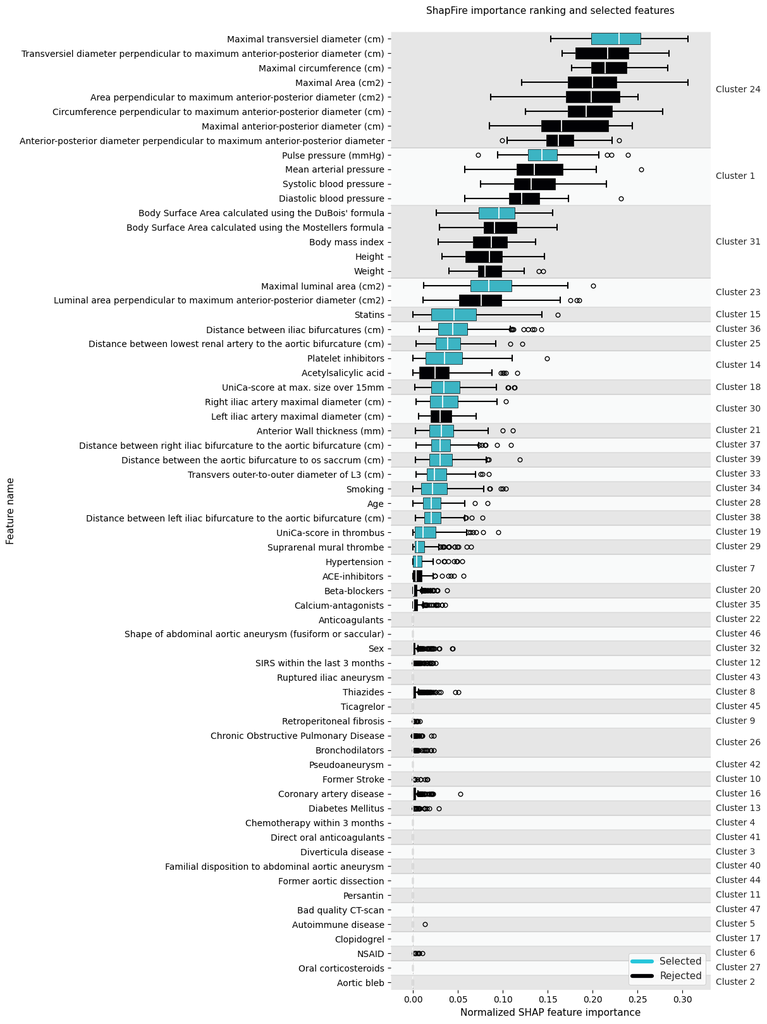

```python
_, _ = sf.plot_importance(plot_type="boxplot")
```

For the sake of completeness, the final ShapFire-selected feature subset (FS1) is also printed explicitly in the next cell.

```python
list(sf.selected_features)
```

```
['Maximal transversiel diameter (cm)',
 'Pulse pressure (mmHg)',
 "Body Surface Area calculated using the DuBois' formula",
 'Maximal luminal area (cm2)',
 'Statins',
 'Distance between iliac bifurcatures (cm)',
 'Distance between lowest renal artery to the aortic bifurcature (cm)',
 'Platelet inhibitors',
 'UniCa-score at max. size over 15mm',
 'Right iliac artery maximal diameter (cm)',
 'Anterior Wall thickness (mm)',
 'Distance between right iliac bifurcature to the aortic bifurcature (cm)',
 'Distance between the aortic bifurcature to os saccrum (cm)',
 'Transvers outer-to-outer diameter of L3 (cm)',
 'Smoking',
 'Age',
 'Distance between left iliac bifurcature to the aortic bifurcature (cm)',
 'UniCa-score in thrombus',
 'Suprarenal mural thrombe',
 'Hypertension']
```

## 0.4 Model Comparison Plan

In the subsequent sections, we compare models trained and tuned with different feature sets:

- **FS1**: ShapFire-selected features (listed above).
- **FS2**: A single feature `Maximal anterior-posterior diameter (cm)`.
- **FS3**: All available features in the dataset.

The steps executed in the following for each feature set, can be summarized as follows:

- Hyperparameter tuning happens on D1 (using repeated k-fold CV and ROC AUC as the performance measure).
- The final performance is estimated on D2 (using repeated k-fold CV, with fixed features and hyperparameters).

The purpose here to avoid information leakage and make sure unbiased estimates are obtained.

## 1. Model M1: ShapFire-Selected Features (FS1)

## 1.1 Hyperparameter Tuning on D1

We tune `LGBMClassifier` hyperparameters on D1 using repeated k-fold CV with ROC AUC as the performance measure. The grid of values below define the used search ranges:

- `n_estimators`: [100, 250, 500, 1000, 2000]
- `learning_rate`: [0.070, 0.0675, 0.065, 0.0625, 0.0600]
- `boosting_type`: ["gbdt"]
- `objective`: ["binary"]

**Results:**

- `best_score_selected_features` (the mean CV ROC AUC on D1)
- `best_params_selected_features` (the hyperparameters chosen for FS1)

```python
%%capture
estimator_params = {
    "n_estimators": [100, 250, 500, 1000, 2000],
    "learning_rate": [0.070, 0.0675, 0.065, 0.0625, 0.0600],
    "boosting_type": ["gbdt"],
    "objective": ["binary"],
}

best_score_selected_features, best_params_selected_features = hyperparameter_search_helper(
    X=X_preprocess,
    y=y_preprocess,
    feature_names=sf.selected_features,
    n_splits=n_splits,
    n_repeats=n_repeats,
    hyperparameter_search=GridSearchCV,
    estimator_class=estimator_class,
    estimator_params=estimator_params,
    scoring=scoring,
)
```

```python
print("Best score  : ", best_score_selected_features)
print("Using params: ", best_params_selected_features)
```

```
Best score  :  0.8603595585617658
Using params:  {'boosting_type': 'gbdt', 'learning_rate': 0.06, 'n_estimators': 100, 'objective': 'binary'}
```

## 1.2 Unbiased Evaluation on D2 (ROC Curves)

With features (FS1) and hyperparameters fixed from D1, we estimate performance on D2 via repeated k-fold CV and plot ROC curves. This yields an unbiased ROC AUC distribution and its mean.

```
is_classifier
is_classifier
is_classifier
is_classifier
is_classifier
```

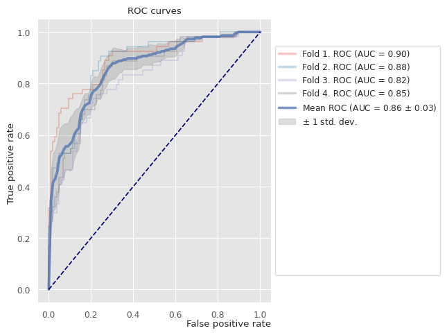

```python
# Train and test the model
refit_helper_selected_features = RefitHelper(
    n_splits=n_splits,
    n_repeats=n_repeats,
    feature_names=sf.selected_features,
    estimator_class=estimator_class,
    estimator_params=best_params_selected_features,
    scoring=scoring,
)
sf.selected_features
refit_helper_selected_features.feature_names = sf.selected_features
refit_helper_selected_features.fit(X_final, pd.Series(y_final))

# Plot performance estimates
fig, ax = plot_roc_curve(df=refit_helper_selected_features.history)

# Save figure
plt.tight_layout()
fig.savefig('img/fs1_roc_auc.png', dpi=300)
```

## 1.3 Cross-Validation Results (by Fold)

Display per-fold metrics at multiple probability thresholds.

```python
pd.set_option("display.max_rows", None)

# Helper function to extract and subsequently aggregate results
def extract_stats(df):
    dfs_list = []
    for fold, row in df.iterrows():
        _df = pd.DataFrame(data = row["score"]["conf_matrices"])
        _df["fold"] = fold
        dfs_list.append(_df)
    stats_df = pd.concat(dfs_list).set_index(["fold"])
    return stats_df, stats_df.groupby(["probability"]).mean()

# Extract results
stats_df, stats_mean = extract_stats(df=refit_helper_selected_features.history)
```

```python
_stats_df = stats_df.copy()
_stats_df["fold"] = stats_df.index
_stats_df.set_index(["fold", "probability"])
```

| fold | probability | true_positives | true_negatives | false_positives | false_negatives | accuracy | specitivity | sensitivity | youden_index |
| --- | --- | --- | --- | --- | --- | --- | --- | --- | --- |
| 0 | 0.00 | 54 | 0 | 106 | 0 | 0.337500 | 0.000000 | 1.000000 | 0.000000 |
|  | 0.05 | 51 | 50 | 56 | 3 | 0.631250 | 0.471698 | 0.944444 | 0.416143 |
|  | 0.10 | 50 | 71 | 35 | 4 | 0.756250 | 0.669811 | 0.925926 | 0.595737 |
|  | 0.15 | 45 | 79 | 27 | 9 | 0.775000 | 0.745283 | 0.833333 | 0.578616 |
|  | 0.20 | 43 | 81 | 25 | 11 | 0.775000 | 0.764151 | 0.796296 | 0.560447 |
|  | 0.25 | 41 | 89 | 17 | 13 | 0.812500 | 0.839623 | 0.759259 | 0.598882 |
|  | 0.30 | 41 | 93 | 13 | 13 | 0.837500 | 0.877358 | 0.759259 | 0.636618 |
|  | 0.35 | 38 | 99 | 7 | 16 | 0.856250 | 0.933962 | 0.703704 | 0.637666 |
|  | 0.40 | 38 | 99 | 7 | 16 | 0.856250 | 0.933962 | 0.703704 | 0.637666 |
|  | 0.45 | 34 | 101 | 5 | 20 | 0.843750 | 0.952830 | 0.629630 | 0.582460 |
|  | 0.50 | 34 | 102 | 4 | 20 | 0.850000 | 0.962264 | 0.629630 | 0.591894 |
|  | 0.55 | 32 | 102 | 4 | 22 | 0.837500 | 0.962264 | 0.592593 | 0.554857 |
|  | 0.60 | 31 | 103 | 3 | 23 | 0.837500 | 0.971698 | 0.574074 | 0.545772 |
|  | 0.65 | 31 | 104 | 2 | 23 | 0.843750 | 0.981132 | 0.574074 | 0.555206 |
|  | 0.70 | 27 | 105 | 1 | 27 | 0.825000 | 0.990566 | 0.500000 | 0.490566 |
|  | 0.75 | 23 | 105 | 1 | 31 | 0.800000 | 0.990566 | 0.425926 | 0.416492 |
|  | 0.80 | 17 | 105 | 1 | 37 | 0.762500 | 0.990566 | 0.314815 | 0.305381 |
|  | 0.85 | 13 | 106 | 0 | 41 | 0.743750 | 1.000000 | 0.240741 | 0.240741 |
|  | 0.90 | 9 | 106 | 0 | 45 | 0.718750 | 1.000000 | 0.166667 | 0.166667 |
|  | 0.95 | 3 | 106 | 0 | 51 | 0.681250 | 1.000000 | 0.055556 | 0.055556 |
|  | 1.00 | 0 | 106 | 0 | 54 | 0.662500 | 1.000000 | 0.000000 | 0.000000 |
| 1 | 0.00 | 53 | 0 | 106 | 0 | 0.333333 | 0.000000 | 1.000000 | 0.000000 |
|  | 0.05 | 51 | 51 | 55 | 2 | 0.641509 | 0.481132 | 0.962264 | 0.443396 |
|  | 0.10 | 50 | 67 | 39 | 3 | 0.735849 | 0.632075 | 0.943396 | 0.575472 |
|  | 0.15 | 49 | 72 | 34 | 4 | 0.761006 | 0.679245 | 0.924528 | 0.603774 |
|  | 0.20 | 48 | 79 | 27 | 5 | 0.798742 | 0.745283 | 0.905660 | 0.650943 |
|  | 0.25 | 47 | 81 | 25 | 6 | 0.805031 | 0.764151 | 0.886792 | 0.650943 |
|  | 0.30 | 44 | 85 | 21 | 9 | 0.811321 | 0.801887 | 0.830189 | 0.632075 |
|  | 0.35 | 38 | 88 | 18 | 15 | 0.792453 | 0.830189 | 0.716981 | 0.547170 |
|  | 0.40 | 34 | 90 | 16 | 19 | 0.779874 | 0.849057 | 0.641509 | 0.490566 |

[output cut: 54 more lines]

## 1.4 Cross-Validation Results (Aggregated)

We aggregate metrics over folds to obtain mean values at multiple probability thresholds.

```python
youden_max, row_i = stats_mean["youden_index"].max(), stats_mean["youden_index"].idxmax()
print("Max Youden Index    : ", youden_max)
print("Row (probability)   : ", row_i)
stats_mean
```

```
Max Youden Index    :  0.5779175401816912
Row (probability)   :  0.30000000000000004
```

| probability | true_positives | true_negatives | false_positives | false_negatives | accuracy | specitivity | sensitivity | youden_index |
| --- | --- | --- | --- | --- | --- | --- | --- | --- |
| 0.00 | 53.50 | 0.00 | 106.00 | 0.00 | 0.335417 | 0.000000 | 1.000000 | 0.000000 |
| 0.05 | 49.25 | 50.00 | 56.00 | 4.25 | 0.622209 | 0.471698 | 0.920772 | 0.392470 |
| 0.10 | 47.25 | 68.50 | 37.50 | 6.25 | 0.725678 | 0.646226 | 0.883473 | 0.529700 |
| 0.15 | 45.50 | 75.50 | 30.50 | 8.00 | 0.758618 | 0.712264 | 0.850891 | 0.563155 |
| 0.20 | 44.25 | 79.25 | 26.75 | 9.25 | 0.774322 | 0.747642 | 0.827568 | 0.575210 |
| 0.25 | 41.50 | 84.00 | 22.00 | 12.00 | 0.786812 | 0.792453 | 0.775943 | 0.568396 |
| 0.30 | 40.25 | 87.50 | 18.50 | 13.25 | 0.800924 | 0.825472 | 0.752446 | 0.577918 |
| 0.35 | 37.25 | 90.25 | 15.75 | 16.25 | 0.799332 | 0.851415 | 0.696191 | 0.547607 |
| 0.40 | 34.75 | 91.00 | 15.00 | 18.75 | 0.788345 | 0.858491 | 0.649196 | 0.507687 |
| 0.45 | 32.50 | 92.75 | 13.25 | 21.00 | 0.785210 | 0.875000 | 0.607180 | 0.482180 |
| 0.50 | 31.50 | 95.50 | 10.50 | 22.00 | 0.796197 | 0.900943 | 0.588574 | 0.489518 |
| 0.55 | 30.50 | 96.25 | 9.75 | 23.00 | 0.794654 | 0.908019 | 0.569969 | 0.477987 |
| 0.60 | 28.75 | 97.25 | 8.75 | 24.75 | 0.789937 | 0.917453 | 0.537212 | 0.454665 |
| 0.65 | 27.00 | 98.75 | 7.25 | 26.50 | 0.788375 | 0.931604 | 0.504455 | 0.436059 |
| 0.70 | 24.75 | 101.25 | 4.75 | 28.75 | 0.789967 | 0.955189 | 0.462614 | 0.417802 |
| 0.75 | 22.00 | 102.50 | 3.50 | 31.50 | 0.780572 | 0.966981 | 0.411338 | 0.378319 |
| 0.80 | 19.00 | 103.25 | 2.75 | 34.50 | 0.766500 | 0.974057 | 0.355433 | 0.329490 |
| 0.85 | 17.00 | 104.00 | 2.00 | 36.50 | 0.758658 | 0.981132 | 0.318047 | 0.299179 |
| 0.90 | 14.00 | 104.75 | 1.25 | 39.50 | 0.744546 | 0.988208 | 0.261967 | 0.250175 |
| 0.95 | 8.50 | 105.75 | 0.25 | 45.00 | 0.716333 | 0.997642 | 0.159067 | 0.156709 |
| 1.00 | 0.00 | 106.00 | 0.00 | 53.50 | 0.664583 | 1.000000 | 0.000000 | 0.000000 |

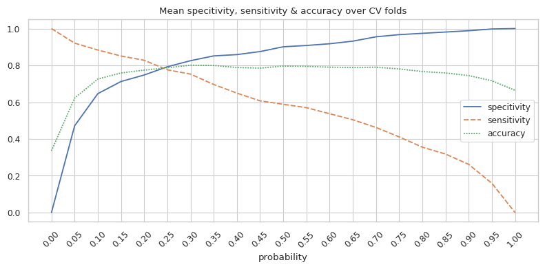

```python
# Plot mean specitivity, sensitivity and accuracy for each probability threshold
sns.lineplot(data=stats_mean[["specitivity", "sensitivity", "accuracy"]])
plt.title("Mean specitivity, sensitivity & accuracy over CV folds")
plt.xticks(stats_mean.index, rotation=45)
fig = plt.gcf()

# Set figure size
fig.set_size_inches(8, 4)
plt.tight_layout()

# Save the figure
fig.savefig('img/fs1_mean_stats.png', dpi=300)
```

# Model M2: A Single Feature (FS2)

In this model, we restrict the input to a single type of measurement, i.e., the `Maximal anterior–posterior diameter (cm)`, i.e., the goal is to evaluate how well this individual feature alone can discriminate between classes, and to provide an interpretable baseline against which more complex feature sets (FS1 and FS3) can be compared.

## 2.1 Hyperparameter Tuning on D1

We tune `LGBMClassifier` hyperparameters on D1 using repeated k-fold CV with ROC AUC as the performance measure. The grid of values below define the used search ranges:

- `n_estimators`: [100, 250, 500, 1000, 2000]
- `learning_rate`: [0.070, 0.0675, 0.065, 0.0625, 0.0600]
- `boosting_type`: ["gbdt"]
- `objective`: ["binary"]

**Results:**

- `best_score_single_feature` (the mean CV ROC AUC on D1)
- `best_params_single_feature` (the hyperparameters chosen for FS2)

```python
%%capture
best_score_single_feature, best_params_single_feature = hyperparameter_search_helper(
    X=X_preprocess,
    y=y_preprocess,
    feature_names=[feature_name_mapping["ap_dia_max_ct"]],
    n_splits=n_splits,
    n_repeats=n_repeats,
    hyperparameter_search=GridSearchCV,
    estimator_class=estimator_class,
    estimator_params=estimator_params,
    scoring=scoring,
)
```

```python
print("Best score  : ", best_score_single_feature)
print("Using params: ", best_params_single_feature)
```

```
Best score  :  0.7434585261658954
Using params:  {'boosting_type': 'gbdt', 'learning_rate': 0.06, 'n_estimators': 100, 'objective': 'binary'}
```

## 2.2 Unbiased Evaluation on D2 (ROC Curves)

With features (FS2) and hyperparameters fixed from D1, we estimate performance on D2 via repeated k-fold CV and plot ROC curves. This yields an unbiased ROC AUC distribution and its mean.

```
is_classifier
is_classifier
is_classifier
is_classifier
is_classifier
```

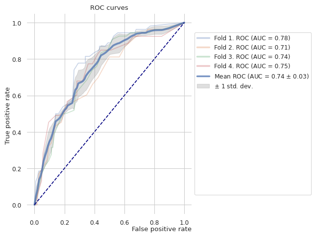

```python
refit_helper_single_feature = RefitHelper(
    n_splits=n_splits,
    n_repeats=n_repeats,
    feature_names=[feature_name_mapping["ap_dia_max_ct"]],
    estimator_class=estimator_class,
    estimator_params=best_params_single_feature,
    scoring=scoring,
)
refit_helper_single_feature.fit(X_final[[feature_name_mapping["ap_dia_max_ct"]]], pd.Series(y_final))

fig, ax = plot_roc_curve(df=refit_helper_single_feature.history)

# Save figure
plt.tight_layout()
fig.savefig('img/fs2_roc_auc.png', dpi=300)
```

## 2.3 Cross-Validated Results (by Fold)

Display per-fold metrics at multiple probability thresholds.

```python
# Extract stats/results
stats_df, stats_mean = extract_stats(df=refit_helper_single_feature.history)

_stats_df = stats_df.copy()
_stats_df["fold"] = stats_df.index
_stats_df.set_index(["fold", "probability"])
```

| fold | probability | true_positives | true_negatives | false_positives | false_negatives | accuracy | specitivity | sensitivity | youden_index |
| --- | --- | --- | --- | --- | --- | --- | --- | --- | --- |
| 0 | 0.00 | 54 | 0 | 106 | 0 | 0.337500 | 0.000000 | 1.000000 | 0.000000 |
|  | 0.05 | 52 | 27 | 79 | 2 | 0.493750 | 0.254717 | 0.962963 | 0.217680 |
|  | 0.10 | 52 | 30 | 76 | 2 | 0.512500 | 0.283019 | 0.962963 | 0.245982 |
|  | 0.15 | 50 | 50 | 56 | 4 | 0.625000 | 0.471698 | 0.925926 | 0.397624 |
|  | 0.20 | 48 | 52 | 54 | 6 | 0.625000 | 0.490566 | 0.888889 | 0.379455 |
|  | 0.25 | 45 | 64 | 42 | 9 | 0.681250 | 0.603774 | 0.833333 | 0.437107 |
|  | 0.30 | 44 | 70 | 36 | 10 | 0.712500 | 0.660377 | 0.814815 | 0.475192 |
|  | 0.35 | 42 | 71 | 35 | 12 | 0.706250 | 0.669811 | 0.777778 | 0.447589 |
|  | 0.40 | 31 | 79 | 27 | 23 | 0.687500 | 0.745283 | 0.574074 | 0.319357 |
|  | 0.45 | 29 | 86 | 20 | 25 | 0.718750 | 0.811321 | 0.537037 | 0.348358 |
|  | 0.50 | 29 | 86 | 20 | 25 | 0.718750 | 0.811321 | 0.537037 | 0.348358 |
|  | 0.55 | 27 | 91 | 15 | 27 | 0.737500 | 0.858491 | 0.500000 | 0.358491 |
|  | 0.60 | 10 | 101 | 5 | 44 | 0.693750 | 0.952830 | 0.185185 | 0.138015 |
|  | 0.65 | 8 | 104 | 2 | 46 | 0.700000 | 0.981132 | 0.148148 | 0.129280 |
|  | 0.70 | 7 | 105 | 1 | 47 | 0.700000 | 0.990566 | 0.129630 | 0.120196 |
|  | 0.75 | 7 | 105 | 1 | 47 | 0.700000 | 0.990566 | 0.129630 | 0.120196 |
|  | 0.80 | 0 | 106 | 0 | 54 | 0.662500 | 1.000000 | 0.000000 | 0.000000 |
|  | 0.85 | 0 | 106 | 0 | 54 | 0.662500 | 1.000000 | 0.000000 | 0.000000 |
|  | 0.90 | 0 | 106 | 0 | 54 | 0.662500 | 1.000000 | 0.000000 | 0.000000 |
|  | 0.95 | 0 | 106 | 0 | 54 | 0.662500 | 1.000000 | 0.000000 | 0.000000 |
|  | 1.00 | 0 | 106 | 0 | 54 | 0.662500 | 1.000000 | 0.000000 | 0.000000 |
| 1 | 0.00 | 53 | 0 | 106 | 0 | 0.333333 | 0.000000 | 1.000000 | 0.000000 |
|  | 0.05 | 51 | 21 | 85 | 2 | 0.452830 | 0.198113 | 0.962264 | 0.160377 |
|  | 0.10 | 49 | 34 | 72 | 4 | 0.522013 | 0.320755 | 0.924528 | 0.245283 |
|  | 0.15 | 43 | 46 | 60 | 10 | 0.559748 | 0.433962 | 0.811321 | 0.245283 |
|  | 0.20 | 37 | 61 | 45 | 16 | 0.616352 | 0.575472 | 0.698113 | 0.273585 |
|  | 0.25 | 32 | 69 | 37 | 21 | 0.635220 | 0.650943 | 0.603774 | 0.254717 |
|  | 0.30 | 32 | 69 | 37 | 21 | 0.635220 | 0.650943 | 0.603774 | 0.254717 |
|  | 0.35 | 29 | 83 | 23 | 24 | 0.704403 | 0.783019 | 0.547170 | 0.330189 |
|  | 0.40 | 29 | 83 | 23 | 24 | 0.704403 | 0.783019 | 0.547170 | 0.330189 |

[output cut: 54 more lines]

## 2.4 Cross-Validation Results (Aggregated)

We aggregate metrics over folds to obtain mean values at multiple probability thresholds.

```python
youden_max, row_i = stats_mean["youden_index"].max(), stats_mean["youden_index"].idxmax()
print("Max Youden Index    : ", youden_max)
print("Row (probability)   : ", row_i)
stats_mean
```

```
Max Youden Index    :  0.38259958071278827
Row (probability)   :  0.35000000000000003
```

| probability | true_positives | true_negatives | false_positives | false_negatives | accuracy | specitivity | sensitivity | youden_index |
| --- | --- | --- | --- | --- | --- | --- | --- | --- |
| 0.00 | 53.50 | 0.00 | 106.00 | 0.00 | 0.335417 | 0.000000 | 1.000000 | 0.000000 |
| 0.05 | 52.00 | 17.25 | 88.75 | 1.50 | 0.434041 | 0.162736 | 0.972048 | 0.134783 |
| 0.10 | 50.25 | 31.25 | 74.75 | 3.25 | 0.511026 | 0.294811 | 0.939116 | 0.233927 |
| 0.15 | 47.25 | 46.75 | 59.25 | 6.25 | 0.589230 | 0.441038 | 0.882862 | 0.323899 |
| 0.20 | 43.75 | 57.75 | 48.25 | 9.75 | 0.636360 | 0.544811 | 0.817348 | 0.362159 |
| 0.25 | 40.25 | 64.75 | 41.25 | 13.25 | 0.658274 | 0.610849 | 0.752009 | 0.362858 |
| 0.30 | 38.50 | 68.25 | 37.75 | 15.00 | 0.669222 | 0.643868 | 0.719340 | 0.363208 |
| 0.35 | 36.25 | 74.75 | 31.25 | 17.25 | 0.695922 | 0.705189 | 0.677411 | 0.382600 |
| 0.40 | 30.75 | 80.00 | 26.00 | 22.75 | 0.694349 | 0.754717 | 0.575122 | 0.329839 |
| 0.45 | 28.25 | 84.50 | 21.50 | 25.25 | 0.706879 | 0.797170 | 0.528127 | 0.325297 |
| 0.50 | 27.00 | 85.75 | 20.25 | 26.50 | 0.706879 | 0.808962 | 0.504804 | 0.313767 |
| 0.55 | 25.25 | 89.75 | 16.25 | 28.25 | 0.721000 | 0.846698 | 0.472222 | 0.318920 |
| 0.60 | 19.50 | 93.75 | 12.25 | 34.00 | 0.710092 | 0.884434 | 0.365566 | 0.250000 |
| 0.65 | 17.75 | 96.25 | 9.75 | 35.75 | 0.714800 | 0.908019 | 0.332722 | 0.240741 |
| 0.70 | 13.25 | 98.75 | 7.25 | 40.25 | 0.702231 | 0.931604 | 0.248253 | 0.179857 |
| 0.75 | 7.00 | 103.00 | 3.00 | 46.50 | 0.689642 | 0.971698 | 0.130416 | 0.102114 |
| 0.80 | 2.50 | 104.25 | 1.75 | 51.00 | 0.669261 | 0.983491 | 0.046384 | 0.029874 |
| 0.85 | 2.25 | 104.75 | 1.25 | 51.25 | 0.670833 | 0.988208 | 0.041667 | 0.029874 |
| 0.90 | 0.00 | 106.00 | 0.00 | 53.50 | 0.664583 | 1.000000 | 0.000000 | 0.000000 |
| 0.95 | 0.00 | 106.00 | 0.00 | 53.50 | 0.664583 | 1.000000 | 0.000000 | 0.000000 |
| 1.00 | 0.00 | 106.00 | 0.00 | 53.50 | 0.664583 | 1.000000 | 0.000000 | 0.000000 |

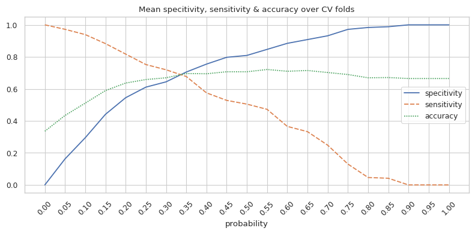

```python
# Plot mean specitivity, sensitivity and accuracy for each probability threshold
sns.lineplot(data=stats_mean[["specitivity", "sensitivity", "accuracy"]])
plt.title("Mean specitivity, sensitivity & accuracy over CV folds")
plt.xticks(stats_mean.index, rotation=45)
fig = plt.gcf()

# Set figure size
fig.set_size_inches(8, 4)
plt.tight_layout()

# Save the figure
fig.savefig('img/fs2_mean_stats.png', dpi=300)
```

# 3. Model M3: All Features (FS3)

## 3.1 Hyperparameter Tuning on D1

Using all available features we tune the hyperparameters of a machine learning model using the preprocessing dataset D1.

```python
%%capture
best_score_all_features, best_params_all_features = hyperparameter_search_helper(
    X=X_preprocess,
    y=y_preprocess,
    feature_names=X_final.columns.to_list(),
    n_splits=n_splits,
    n_repeats=n_repeats,
    hyperparameter_search=GridSearchCV,
    estimator_class=estimator_class,
    estimator_params=estimator_params,
    scoring=scoring,
)
```

```python
print("Best score  : ", best_score_all_features)
print("Using params: ", best_params_all_features)
```

```
Best score  :  0.8829209683161268
Using params:  {'boosting_type': 'gbdt', 'learning_rate': 0.0675, 'n_estimators': 100, 'objective': 'binary'}
```

## 3.2 Unbiased Evaluation on D2 (ROC Curves)

With features (FS3) and hyperparameters fixed from D1, we estimate performance on D2 via repeated k-fold CV and plot ROC curves. This yields an unbiased ROC AUC distribution and its mean.

```
is_classifier
is_classifier
is_classifier
is_classifier
is_classifier
```

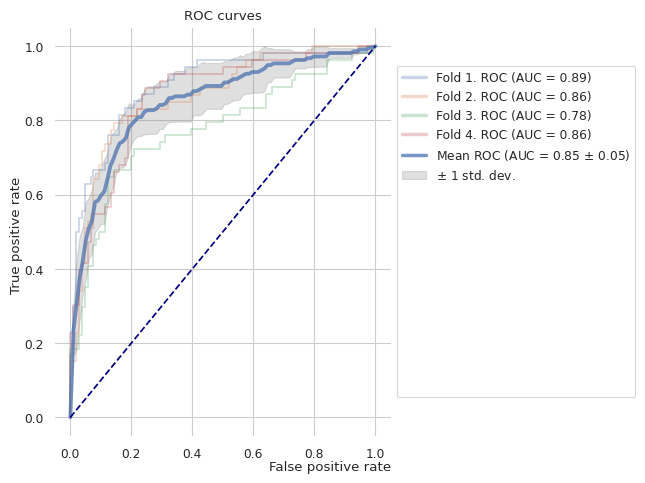

```python
refit_helper_baseline_features = RefitHelper(
    n_splits=n_splits,
    n_repeats=n_repeats,
    feature_names=X_final.columns.to_list(),
    estimator_class=estimator_class,
    estimator_params=best_params_all_features,
    scoring=scoring,
)
refit_helper_baseline_features.fit(X_final, pd.Series(y_final))

fig, ax = plot_roc_curve(df=refit_helper_baseline_features.history)

# Save figure
plt.tight_layout()
fig.savefig('img/fs3_roc_auc.png', dpi=300)
```

## 3.3 Cross-Validated Results (by Fold)

Display per-fold metrics at multiple probability thresholds.

```python
# Extract stats/results
stats_df, stats_mean = extract_stats(df=refit_helper_baseline_features.history)

_stats_df = stats_df.copy()
_stats_df["fold"] = stats_df.index
_stats_df.set_index(["fold", "probability"])
```

| fold | probability | true_positives | true_negatives | false_positives | false_negatives | accuracy | specitivity | sensitivity | youden_index |
| --- | --- | --- | --- | --- | --- | --- | --- | --- | --- |
| 0 | 0.00 | 54 | 0 | 106 | 0 | 0.337500 | 0.000000 | 1.000000 | 0.000000 |
|  | 0.05 | 51 | 65 | 41 | 3 | 0.725000 | 0.613208 | 0.944444 | 0.557652 |
|  | 0.10 | 47 | 81 | 25 | 7 | 0.800000 | 0.764151 | 0.870370 | 0.634521 |
|  | 0.15 | 45 | 86 | 20 | 9 | 0.818750 | 0.811321 | 0.833333 | 0.644654 |
|  | 0.20 | 42 | 89 | 17 | 12 | 0.818750 | 0.839623 | 0.777778 | 0.617400 |
|  | 0.25 | 41 | 92 | 14 | 13 | 0.831250 | 0.867925 | 0.759259 | 0.627184 |
|  | 0.30 | 39 | 93 | 13 | 15 | 0.825000 | 0.877358 | 0.722222 | 0.599581 |
|  | 0.35 | 37 | 93 | 13 | 17 | 0.812500 | 0.877358 | 0.685185 | 0.562544 |
|  | 0.40 | 36 | 95 | 11 | 18 | 0.818750 | 0.896226 | 0.666667 | 0.562893 |
|  | 0.45 | 36 | 98 | 8 | 18 | 0.837500 | 0.924528 | 0.666667 | 0.591195 |
|  | 0.50 | 34 | 100 | 6 | 20 | 0.837500 | 0.943396 | 0.629630 | 0.573026 |
|  | 0.55 | 34 | 101 | 5 | 20 | 0.843750 | 0.952830 | 0.629630 | 0.582460 |
|  | 0.60 | 29 | 102 | 4 | 25 | 0.818750 | 0.962264 | 0.537037 | 0.499301 |
|  | 0.65 | 27 | 103 | 3 | 27 | 0.812500 | 0.971698 | 0.500000 | 0.471698 |
|  | 0.70 | 27 | 103 | 3 | 27 | 0.812500 | 0.971698 | 0.500000 | 0.471698 |
|  | 0.75 | 23 | 104 | 2 | 31 | 0.793750 | 0.981132 | 0.425926 | 0.407058 |
|  | 0.80 | 22 | 104 | 2 | 32 | 0.787500 | 0.981132 | 0.407407 | 0.388539 |
|  | 0.85 | 17 | 104 | 2 | 37 | 0.756250 | 0.981132 | 0.314815 | 0.295947 |
|  | 0.90 | 13 | 105 | 1 | 41 | 0.737500 | 0.990566 | 0.240741 | 0.231307 |
|  | 0.95 | 7 | 106 | 0 | 47 | 0.706250 | 1.000000 | 0.129630 | 0.129630 |
|  | 1.00 | 0 | 106 | 0 | 54 | 0.662500 | 1.000000 | 0.000000 | 0.000000 |
| 1 | 0.00 | 53 | 0 | 106 | 0 | 0.333333 | 0.000000 | 1.000000 | 0.000000 |
|  | 0.05 | 47 | 52 | 54 | 6 | 0.622642 | 0.490566 | 0.886792 | 0.377358 |
|  | 0.10 | 45 | 71 | 35 | 8 | 0.729560 | 0.669811 | 0.849057 | 0.518868 |
|  | 0.15 | 44 | 78 | 28 | 9 | 0.767296 | 0.735849 | 0.830189 | 0.566038 |
|  | 0.20 | 44 | 80 | 26 | 9 | 0.779874 | 0.754717 | 0.830189 | 0.584906 |
|  | 0.25 | 44 | 83 | 23 | 9 | 0.798742 | 0.783019 | 0.830189 | 0.613208 |
|  | 0.30 | 43 | 85 | 21 | 10 | 0.805031 | 0.801887 | 0.811321 | 0.613208 |
|  | 0.35 | 43 | 88 | 18 | 10 | 0.823899 | 0.830189 | 0.811321 | 0.641509 |
|  | 0.40 | 39 | 93 | 13 | 14 | 0.830189 | 0.877358 | 0.735849 | 0.613208 |

[output cut: 54 more lines]

## 3.4 Cross-Validation Results (Aggregated)

We aggregate metrics over folds to obtain mean values at multiple probability thresholds.

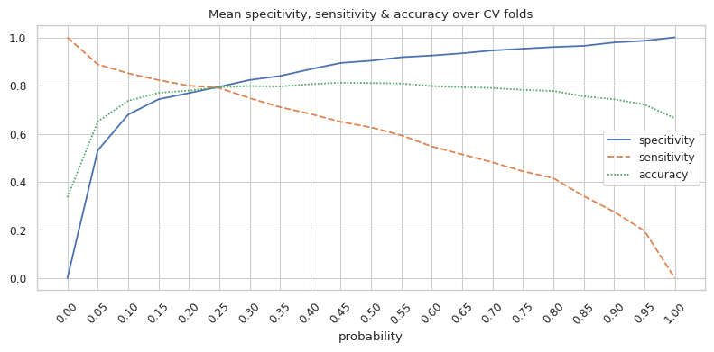

```python
# Plot mean specitivity, sensitivity and accuracy for each probability threshold
sns.lineplot(data=stats_mean[["specitivity", "sensitivity", "accuracy"]])
plt.title("Mean specitivity, sensitivity & accuracy over CV folds")
plt.xticks(stats_mean.index, rotation=45)
fig = plt.gcf()

# Set figure size
fig.set_size_inches(8, 4)
plt.tight_layout()

# Save the figure
fig.savefig('img/fs3_mean_stats.png', dpi=300)
```

# 4. Combined Analyses

## 4.1 Mean ROC Curves: M1 vs M2 vs M3

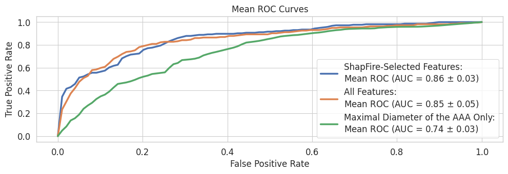

```python
def extract_statistics(df):
    # Make sure valid data pertaining to the 'roc_auc' scoring function is
    # actually available and set in the 'self.shapfire._history' dataframe
    try:
        dict_: dict[str, typing.Any] = df["score"].iat[0]
        fpr, tpr, roc_auc = dict_["fpr"], dict_["tpr"], dict_["roc_auc"]
    except KeyError:
        raise ValueError(
            "This plotting function can only be called if valid data "
            + "pertaining to the 'roc_auc' score is availble.."
        )
    # Extract necessary data for plotting
    tprs = []
    aucs = []
    mean_fpr = np.linspace(start=0, stop=1, num=100)
    counter = 1
    for _, row in df.iterrows():
        score: dict[str, typing.Any] = row["score"]
        fpr, tpr, roc_auc = score["fpr"], score["tpr"], score["roc_auc"]
        # Plot individual ROC lines
        counter += 1

        # Perform one-dimensional linear interpolation for monotonically
        # increasing sample points
        interp_tpr = np.interp(x=mean_fpr, xp=fpr, fp=tpr)
        interp_tpr[0] = 0.0
        tprs.append(interp_tpr)
        aucs.append(roc_auc)

    # Plot mean of ROC lines
    mean_tpr = np.mean(tprs, axis=0)
    mean_tpr[-1] = 1.0
    mean_auc = auc(mean_fpr, mean_tpr)
    std_auc = np.std(aucs, ddof=1)
    return mean_fpr, mean_tpr, mean_auc, std_auc

fig, ax = plt.subplots(nrows=1, ncols=1, figsize=(10, 3.5))

mean_fpr, mean_tpr, mean_auc, std_auc = extract_statistics(refit_helper_selected_features.history)
ax.plot(
    mean_fpr, mean_tpr,
    linewidth=2.5,
    label=f"ShapFire-Selected Features:\n" + r"Mean ROC (AUC = %0.2f $\pm$ %0.2f)" % (mean_auc, std_auc),
)

mean_fpr, mean_tpr, mean_auc, std_auc = extract_statistics(refit_helper_baseline_features.history)
ax.plot(
    mean_fpr, mean_tpr,
    linewidth=2.5,
    label=f"All Features:\n" + r"Mean ROC (AUC = %0.2f $\pm$ %0.2f)" % (mean_auc, std_auc)
)

mean_fpr, mean_tpr, mean_auc, std_auc = extract_statistics(refit_helper_single_feature.history)
ax.plot(
    mean_fpr, mean_tpr,
    linewidth=2.5,
    label=f"Maximal Diameter of the AAA Only:\n" + r"Mean ROC (AUC = %0.2f $\pm$ %0.2f)" % (mean_auc, std_auc),
)
ax.grid(True)
plt.title("Mean ROC Curves",fontsize=12)
plt.xlabel("False Positive Rate", fontsize=12)
plt.ylabel("True Positive Rate", fontsize=12)
plt.legend(fontsize=12, fancybox=True)
plt.yticks(fontsize=12)
plt.xticks(fontsize=12)
fig.tight_layout()

# Save the figure
fig.savefig('img/m1_m2_m3_comparison.png', dpi=300)
```

## 4.2 Hypothesis Testing

To assess whether differences in model performance are statistically significant, we use paired tests on the per-fold ROC AUC values obtained from identical CV splits. Specifically, we apply paired t-tests to compare mean ROC AUCs between models.

The code below collects the per-fold ROC AUC values for each model type (M1, M2, M3), which serve as the paired inputs for hypothesis testing.

```python
single_feature_roc_auc = []
selected_feature_roc_auc = []
baseline_feature_roc_auc = []
for i in range(0, 4):
    single_feature_roc_auc.append(refit_helper_single_feature.history["score"].iat[i]["roc_auc"])
    selected_feature_roc_auc.append(refit_helper_selected_features.history["score"].iat[i]["roc_auc"])
    baseline_feature_roc_auc.append(refit_helper_baseline_features.history["score"].iat[i]["roc_auc"])
```

### Display ROC AUC: ShapFire-selected Features (M1, FS1)

```python
for item in selected_feature_roc_auc:
    print(item)
```

```
0.8950034940600978
0.8784264862940547
0.8170859538784067
0.845318618725525
```

### Display ROC AUC: Single Feature (M2, FS2)

```python
for item in single_feature_roc_auc:
    print(item)
```

```
0.7834556254367575
0.7129761480954078
0.7363731656184486
0.7469740121039515
```

```python
for item in baseline_feature_roc_auc:
    print(item)
```

```
0.893780573025856
0.8648985404058385
0.7756813417190775
0.8622285510857957
```

## 4.2.1 Comparing M1 vs. M2

```python
t_stat, p_value = ttest_rel(selected_feature_roc_auc, single_feature_roc_auc)

print(f"t-statistic: {t_stat}, p-value: {p_value}")
```

```
t-statistic: 6.239902669217837, p-value: 0.008301808287386357
```

## 4.2.2 Comparing M1 vs. M3

```python
t_stat, p_value = ttest_rel(selected_feature_roc_auc, baseline_feature_roc_auc)

print(f"t-statistic: {t_stat}, p-value: {p_value}")
```

```
t-statistic: 0.8011552678679572, p-value: 0.4816223826844377
```

## 4.2.3 Comparing M2 vs. M3

```python
t_stat, p_value = ttest_rel(single_feature_roc_auc, baseline_feature_roc_auc)

print(f"t-statistic: {t_stat}, p-value: {p_value}")
```

```
t-statistic: -4.427109512236837, p-value: 0.021408276672975665
```

## 4.3 Save Models

To prepare models for external validation and downstream use, we re-train each final classifier on the entire dataset using the different feature sets and tuned hyperparameters. In this context, the helper function `save_artifacts` exports the following artifacts:

- **Model**: LightGBM booster saved in native format (`model.txt`).
- **Feature schema** (`schema.json`):
  - strict feature order,
  - pandas dtypes,
  - categorical feature list,
  - missing-value policy,
  - label policy (threshold used).
- **Parameters & metadata** (`params.json`):
  - hyperparameters,
  - best iteration (if available),
  - class labels,
  - optional notes.

```python
def save_artifacts(
    clf: lgb.LGBMClassifier,
    X,
    export_dir="export",
    threshold: float = 0.5,
    notes: str = ""
):
    p = Path(export_dir); p.mkdir(parents=True, exist_ok=True)

    # Save model
    booster = clf.booster_
    model_path = p / "model.txt"
    booster.save_model(str(model_path))

    # Save feature schema
    feature_names = list(X.columns)
    dtypes = {c: str(X[c].dtype) for c in feature_names}
    # If native categorical features are used, store them explicitly
    cat_feats = getattr(clf, "categorical_feature_", None)
    if cat_feats is None:
        # Otherwise fall back to anything that looks categorical
        cat_feats = [c for c in feature_names if isinstance(X[c], pd.CategoricalDtype) or X[c].dtype == "object"]

    schema = {
        "feature_names": feature_names,             # strict order!
        "dtypes": dtypes,                           # pandas dtype strings
        "categorical_feature": list(cat_feats),     # columns treated as categorical
        "missing_value_policy": "pass-through (NaN)",
        "label_policy": {"type": "threshold", "threshold": threshold},  # for classifiers
    }
    (p / "schema.json").write_text(json.dumps(schema, indent=2))

    # Save params & training metadata
    params = clf.get_params(deep=True)
    meta = {
        "params": params,
        "best_iteration": getattr(clf, "best_iteration_", None),
        "classes_": getattr(clf, "classes_", None) if hasattr(clf, "classes_") else None,
        "notes": notes,
    }
    (p / "params.json").write_text(
        json.dumps(meta, indent=2, default=lambda o: o if isinstance(o, (int, float, str, list, dict, type(None))) else str(o))
    )

    # # Save environment info
    # env_lines = [
    #     f"python: {platform.python_version()}",
    #     f"lightgbm: {lgb.__version__}",
    #     f"numpy: {np.__version__}",
    #     f"pandas: {pd.__version__}",
    #     "hardware: GPU" if "gpu" in str(params).lower() else "hardware: CPU",
    # ]
    # (p / "env.txt").write_text("\n".join(env_lines))

X = pd.concat([X_preprocess, X_final])
y = pd.concat([y_preprocess, y_final])
```

```python
selected_features_prod  = lgb.LGBMClassifier(**best_params_single_feature)
selected_features_prod.fit(X[sf.selected_features], pd.Series(y))
save_artifacts(
    selected_features_prod,
    X=X[sf.selected_features],
    threshold=0.5,
    export_dir="export_selected_features_prod",
    notes="Model using ShapFire-selected features (production model)",
)
```

```python
single_feature_prod = lgb.LGBMClassifier(**best_params_single_feature)
single_feature_prod.fit(X[[feature_name_mapping["ap_dia_max_ct"]]], pd.Series(y))
save_artifacts(
    single_feature_prod,
    X=X[[feature_name_mapping["ap_dia_max_ct"]]],
    threshold=0.5,
    export_dir="export_single_feature_prod",
    notes="Model using a single feature (production model)",
)
```

```python
baseline_features_prod = lgb.LGBMClassifier(**best_params_all_features)
baseline_features_prod.fit(X, pd.Series(y))
save_artifacts(
    baseline_features_prod,
    X=X,
    threshold=0.5,
    export_dir="export_all_features_prod",
    notes="Baseline model using all features (production model)",
)
```